# Risk Factor Analysis

## Outcome Variable

**Outcome Variable:** co_occurence

## Predictor Variables

**Intervention Variable:** ever_underweight06

**Adjustment Set:**

- sex
- arm
- enstunt
- month
- brthmon
- hhwealth_quart
- W_birthwt
- W_birthlen
- W_mage
- W_mhtcm
- W_meducyrs
- W_feducyrs
- delta_month
- delta_brthmon
- delta_hhwealth_quart
- delta_W_birthwt
- delta_W_birthlen
- delta_W_mage
- delta_W_mhtcm
- delta_W_meducyrs
- delta_W_feducyrs

## Stratifying Variables

The analysis was stratified on these variable(s):

- studyid
- country

## Data Summary

| studyid | country | ever_underweight06 | co_occurence | n_cell | n |
| --- | --- | --- | --- | --- | --- |
| ki0047075b-MAL-ED | BANGLADESH | 0 | 0 | 152 | 221 |
| ki0047075b-MAL-ED | BANGLADESH | 0 | 1 | 3 | 221 |
| ki0047075b-MAL-ED | BANGLADESH | 1 | 0 | 55 | 221 |
| ki0047075b-MAL-ED | BANGLADESH | 1 | 1 | 11 | 221 |
| ki0047075b-MAL-ED | BRAZIL | 0 | 0 | 170 | 180 |
| ki0047075b-MAL-ED | BRAZIL | 0 | 1 | 0 | 180 |
| ki0047075b-MAL-ED | BRAZIL | 1 | 0 | 9 | 180 |
| ki0047075b-MAL-ED | BRAZIL | 1 | 1 | 1 | 180 |
| ki0047075b-MAL-ED | INDIA | 0 | 0 | 140 | 228 |
| ki0047075b-MAL-ED | INDIA | 0 | 1 | 0 | 228 |
| ki0047075b-MAL-ED | INDIA | 1 | 0 | 71 | 228 |
| ki0047075b-MAL-ED | INDIA | 1 | 1 | 17 | 228 |
| ki0047075b-MAL-ED | NEPAL | 0 | 0 | 192 | 229 |
| ki0047075b-MAL-ED | NEPAL | 0 | 1 | 0 | 229 |
| ki0047075b-MAL-ED | NEPAL | 1 | 0 | 33 | 229 |
| ki0047075b-MAL-ED | NEPAL | 1 | 1 | 4 | 229 |
| ki0047075b-MAL-ED | PERU | 0 | 0 | 185 | 222 |
| ki0047075b-MAL-ED | PERU | 0 | 1 | 1 | 222 |
| ki0047075b-MAL-ED | PERU | 1 | 0 | 31 | 222 |
| ki0047075b-MAL-ED | PERU | 1 | 1 | 5 | 222 |
| ki0047075b-MAL-ED | SOUTH AFRICA | 0 | 0 | 202 | 241 |
| ki0047075b-MAL-ED | SOUTH AFRICA | 0 | 1 | 2 | 241 |
| ki0047075b-MAL-ED | SOUTH AFRICA | 1 | 0 | 35 | 241 |
| ki0047075b-MAL-ED | SOUTH AFRICA | 1 | 1 | 2 | 241 |
| ki0047075b-MAL-ED | TANZANIA, UNITED REPUBLIC OF | 0 | 0 | 191 | 225 |
| ki0047075b-MAL-ED | TANZANIA, UNITED REPUBLIC OF | 0 | 1 | 0 | 225 |
| ki0047075b-MAL-ED | TANZANIA, UNITED REPUBLIC OF | 1 | 0 | 33 | 225 |
| ki0047075b-MAL-ED | TANZANIA, UNITED REPUBLIC OF | 1 | 1 | 1 | 225 |
| ki1000108-CMC-V-BCS-2002 | INDIA | 0 | 0 | 188 | 369 |
| ki1000108-CMC-V-BCS-2002 | INDIA | 0 | 1 | 1 | 369 |

[output cut: 102 more lines]

The following strata were considered:

- studyid: ki0047075b-MAL-ED, country: BANGLADESH
- studyid: ki0047075b-MAL-ED, country: BRAZIL
- studyid: ki0047075b-MAL-ED, country: INDIA
- studyid: ki0047075b-MAL-ED, country: NEPAL
- studyid: ki0047075b-MAL-ED, country: PERU
- studyid: ki0047075b-MAL-ED, country: SOUTH AFRICA
- studyid: ki0047075b-MAL-ED, country: TANZANIA, UNITED REPUBLIC OF
- studyid: ki1000108-CMC-V-BCS-2002, country: INDIA
- studyid: ki1000108-IRC, country: INDIA
- studyid: ki1000109-EE, country: PAKISTAN
- studyid: ki1000109-ResPak, country: PAKISTAN
- studyid: ki1000304b-SAS-CompFeed, country: INDIA
- studyid: ki1000304b-SAS-FoodSuppl, country: INDIA
- studyid: ki1017093-NIH-Birth, country: BANGLADESH
- studyid: ki1017093b-PROVIDE, country: BANGLADESH
- studyid: ki1017093c-NIH-Crypto, country: BANGLADESH
- studyid: ki1066203-TanzaniaChild2, country: TANZANIA, UNITED REPUBLIC OF
- studyid: ki1101329-Keneba, country: GAMBIA
- studyid: ki1112895-Burkina Faso Zn, country: BURKINA FASO
- studyid: ki1113344-GMS-Nepal, country: NEPAL
- studyid: ki1114097-CMIN, country: BANGLADESH
- studyid: ki1114097-CMIN, country: BRAZIL
- studyid: ki1114097-CMIN, country: GUINEA-BISSAU
- studyid: ki1114097-CMIN, country: PERU
- studyid: ki1114097-CONTENT, country: PERU
- studyid: ki1119695-PROBIT, country: BELARUS
- studyid: ki1126311-ZVITAMBO, country: ZIMBABWE
- studyid: ki1135781-COHORTS, country: GUATEMALA
- studyid: ki1135781-COHORTS, country: PHILIPPINES
- studyid: ki1148112-iLiNS-DOSE, country: MALAWI
- studyid: ki1148112-iLiNS-DYAD-M, country: MALAWI
- studyid: ki1148112-LCNI-5, country: MALAWI
- studyid: kiGH5241-JiVitA-4, country: BANGLADESH

### Dropped Strata

Some strata were dropped due to rare outcomes:

- studyid: ki0047075b-MAL-ED, country: BANGLADESH
- studyid: ki0047075b-MAL-ED, country: BRAZIL
- studyid: ki0047075b-MAL-ED, country: INDIA
- studyid: ki0047075b-MAL-ED, country: NEPAL
- studyid: ki0047075b-MAL-ED, country: PERU
- studyid: ki0047075b-MAL-ED, country: SOUTH AFRICA
- studyid: ki0047075b-MAL-ED, country: TANZANIA, UNITED REPUBLIC OF
- studyid: ki1000108-CMC-V-BCS-2002, country: INDIA
- studyid: ki1000108-IRC, country: INDIA
- studyid: ki1000109-ResPak, country: PAKISTAN
- studyid: ki1112895-Burkina Faso Zn, country: BURKINA FASO
- studyid: ki1114097-CMIN, country: BANGLADESH
- studyid: ki1114097-CMIN, country: BRAZIL
- studyid: ki1114097-CMIN, country: PERU
- studyid: ki1114097-CONTENT, country: PERU
- studyid: ki1119695-PROBIT, country: BELARUS
- studyid: ki1148112-LCNI-5, country: MALAWI

## Methods Detail

We’re interested in the causal parameters $E[Y_a]$ for all values of $a \in \mathcal{A}$. These parameters represent the mean outcome if, possibly contrary to fact, we intervened to set all units to have $A=a$. Under the randomization and positivity assumptions, these are identified by the statistical parameters $\psi_a=E_W[E_{Y|A,W}(Y|A=a,W)]$. In addition, we’re interested in the mean of $Y$, $E[Y]$ under no intervention (the observed mean). We will estimate these parameters by using SuperLearner to fit the relevant likelihood factors – $E_{Y|A,W}(Y|A=a,W)$ and $p(A=a|W)$, and then updating our likelihood fit using a joint TMLE.

For unadjusted analyses ($W=\{\}$), initial likelihoods were estimated using Lrnr_glm to estimate the simple $E(Y|A)$ and Lrnr_mean to estimate $p(A)$. For adjusted analyses, a small library containing Lrnr_glmnet, Lrnr_xgboost, and Lrnr_mean was used.

Having estimated these parameters, we will then use the delta method to estimate relative risks and attributable risks relative to a prespecified baseline level of $A$.

# Results Detail

## Results Plots

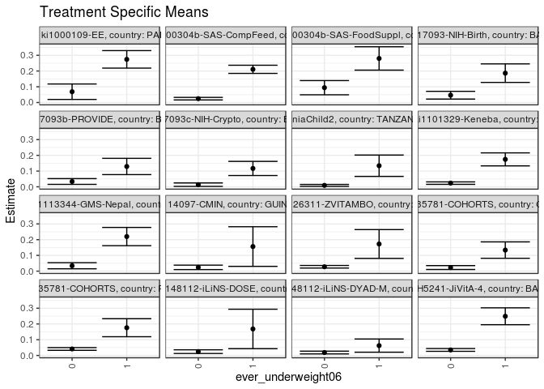

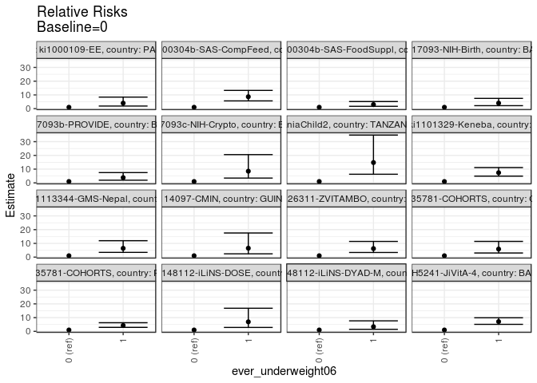

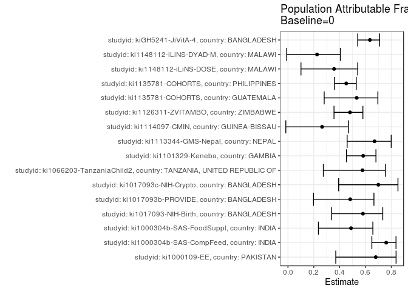

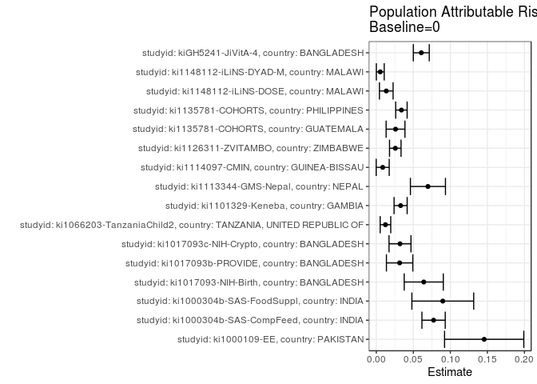

## Results Table

### Parameter: TSM

| studyid | country | intervention_level | baseline_level | estimate | ci_lower | ci_upper |
| --- | --- | --- | --- | --- | --- | --- |
| ki1000109-EE | PAKISTAN | 0 | NA | 0.0686275 | 0.0194937 | 0.1177612 |
| ki1000109-EE | PAKISTAN | 1 | NA | 0.2741935 | 0.2185926 | 0.3297945 |
| ki1000304b-SAS-CompFeed | INDIA | 0 | NA | 0.0243287 | 0.0161683 | 0.0324891 |
| ki1000304b-SAS-CompFeed | INDIA | 1 | NA | 0.2109065 | 0.1850573 | 0.2367557 |
| ki1000304b-SAS-FoodSuppl | INDIA | 0 | NA | 0.0940959 | 0.0488856 | 0.1393061 |
| ki1000304b-SAS-FoodSuppl | INDIA | 1 | NA | 0.2799523 | 0.2057638 | 0.3541408 |
| ki1017093-NIH-Birth | BANGLADESH | 0 | NA | 0.0462923 | 0.0216674 | 0.0709172 |
| ki1017093-NIH-Birth | BANGLADESH | 1 | NA | 0.1864571 | 0.1276633 | 0.2452509 |
| ki1017093b-PROVIDE | BANGLADESH | 0 | NA | 0.0338323 | 0.0155409 | 0.0521237 |
| ki1017093b-PROVIDE | BANGLADESH | 1 | NA | 0.1293446 | 0.0776500 | 0.1810391 |
| ki1017093c-NIH-Crypto | BANGLADESH | 0 | NA | 0.0137300 | 0.0028110 | 0.0246490 |
| ki1017093c-NIH-Crypto | BANGLADESH | 1 | NA | 0.1167513 | 0.0718736 | 0.1616289 |
| ki1066203-TanzaniaChild2 | TANZANIA, UNITED REPUBLIC OF | 0 | NA | 0.0090600 | 0.0028072 | 0.0153129 |
| ki1066203-TanzaniaChild2 | TANZANIA, UNITED REPUBLIC OF | 1 | NA | 0.1340206 | 0.0661904 | 0.2018509 |
| ki1101329-Keneba | GAMBIA | 0 | NA | 0.0235395 | 0.0156638 | 0.0314153 |
| ki1101329-Keneba | GAMBIA | 1 | NA | 0.1744020 | 0.1331684 | 0.2156356 |
| ki1113344-GMS-Nepal | NEPAL | 0 | NA | 0.0342834 | 0.0149555 | 0.0536113 |
| ki1113344-GMS-Nepal | NEPAL | 1 | NA | 0.2197496 | 0.1617898 | 0.2777094 |
| ki1114097-CMIN | GUINEA-BISSAU | 0 | NA | 0.0240700 | 0.0100037 | 0.0381364 |
| ki1114097-CMIN | GUINEA-BISSAU | 1 | NA | 0.1562500 | 0.0303185 | 0.2821815 |
| ki1126311-ZVITAMBO | ZIMBABWE | 0 | NA | 0.0277475 | 0.0194870 | 0.0360079 |
| ki1126311-ZVITAMBO | ZIMBABWE | 1 | NA | 0.1723595 | 0.0808161 | 0.2639029 |
| ki1135781-COHORTS | GUATEMALA | 0 | NA | 0.0228112 | 0.0104448 | 0.0351775 |
| ki1135781-COHORTS | GUATEMALA | 1 | NA | 0.1337468 | 0.0816586 | 0.1858350 |
| ki1135781-COHORTS | PHILIPPINES | 0 | NA | 0.0412722 | 0.0326406 | 0.0499039 |
| ki1135781-COHORTS | PHILIPPINES | 1 | NA | 0.1762006 | 0.1189353 | 0.2334658 |
| ki1148112-iLiNS-DOSE | MALAWI | 0 | NA | 0.0242515 | 0.0126436 | 0.0358594 |
| ki1148112-iLiNS-DOSE | MALAWI | 1 | NA | 0.1683573 | 0.0429393 | 0.2937753 |
| ki1148112-iLiNS-DYAD-M | MALAWI | 0 | NA | 0.0185185 | 0.0097933 | 0.0272438 |
| ki1148112-iLiNS-DYAD-M | MALAWI | 1 | NA | 0.0625000 | 0.0205457 | 0.1044543 |
| kiGH5241-JiVitA-4 | BANGLADESH | 0 | NA | 0.0349988 | 0.0262841 | 0.0437135 |
| kiGH5241-JiVitA-4 | BANGLADESH | 1 | NA | 0.2489546 | 0.1952457 | 0.3026634 |

### Parameter: E(Y)

| studyid | country | intervention_level | baseline_level | estimate | ci_lower | ci_upper |
| --- | --- | --- | --- | --- | --- | --- |
| ki1000109-EE | PAKISTAN | NA | NA | 0.2142857 | 0.1712366 | 0.2573348 |
| ki1000304b-SAS-CompFeed | INDIA | NA | NA | 0.1016680 | 0.0902317 | 0.1131043 |
| ki1000304b-SAS-FoodSuppl | INDIA | NA | NA | 0.1838710 | 0.1406788 | 0.2270631 |
| ki1017093-NIH-Birth | BANGLADESH | NA | NA | 0.1103896 | 0.0817833 | 0.1389959 |
| ki1017093b-PROVIDE | BANGLADESH | NA | NA | 0.0653358 | 0.0446834 | 0.0859881 |
| ki1017093c-NIH-Crypto | BANGLADESH | NA | NA | 0.0457413 | 0.0294659 | 0.0620168 |
| ki1066203-TanzaniaChild2 | TANZANIA, UNITED REPUBLIC OF | NA | NA | 0.0214286 | 0.0123577 | 0.0304995 |
| ki1101329-Keneba | GAMBIA | NA | NA | 0.0563781 | 0.0455871 | 0.0671692 |
| ki1113344-GMS-Nepal | NEPAL | NA | NA | 0.1040146 | 0.0784316 | 0.1295976 |
| ki1114097-CMIN | GUINEA-BISSAU | NA | NA | 0.0327198 | 0.0169357 | 0.0485039 |
| ki1126311-ZVITAMBO | ZIMBABWE | NA | NA | 0.0533893 | 0.0425943 | 0.0641843 |
| ki1135781-COHORTS | GUATEMALA | NA | NA | 0.0487805 | 0.0332288 | 0.0643322 |
| ki1135781-COHORTS | PHILIPPINES | NA | NA | 0.0751910 | 0.0648251 | 0.0855569 |
| ki1148112-iLiNS-DOSE | MALAWI | NA | NA | 0.0377143 | 0.0250845 | 0.0503441 |
| ki1148112-iLiNS-DYAD-M | MALAWI | NA | NA | 0.0239006 | 0.0146399 | 0.0331612 |
| kiGH5241-JiVitA-4 | BANGLADESH | NA | NA | 0.0957734 | 0.0852493 | 0.1062974 |

### Parameter: RR

| studyid | country | intervention_level | baseline_level | estimate | ci_lower | ci_upper |
| --- | --- | --- | --- | --- | --- | --- |
| ki1000109-EE | PAKISTAN | 0 | 0 | 1.000000 | 1.000000 | 1.000000 |
| ki1000109-EE | PAKISTAN | 1 | 0 | 3.995392 | 1.898434 | 8.408589 |
| ki1000304b-SAS-CompFeed | INDIA | 0 | 0 | 1.000000 | 1.000000 | 1.000000 |
| ki1000304b-SAS-CompFeed | INDIA | 1 | 0 | 8.669033 | 5.657010 | 13.284778 |
| ki1000304b-SAS-FoodSuppl | INDIA | 0 | 0 | 1.000000 | 1.000000 | 1.000000 |
| ki1000304b-SAS-FoodSuppl | INDIA | 1 | 0 | 2.975182 | 1.715062 | 5.161160 |
| ki1017093-NIH-Birth | BANGLADESH | 0 | 0 | 1.000000 | 1.000000 | 1.000000 |
| ki1017093-NIH-Birth | BANGLADESH | 1 | 0 | 4.027822 | 2.169407 | 7.478245 |
| ki1017093b-PROVIDE | BANGLADESH | 0 | 0 | 1.000000 | 1.000000 | 1.000000 |
| ki1017093b-PROVIDE | BANGLADESH | 1 | 0 | 3.823110 | 1.950770 | 7.492513 |
| ki1017093c-NIH-Crypto | BANGLADESH | 0 | 0 | 1.000000 | 1.000000 | 1.000000 |
| ki1017093c-NIH-Crypto | BANGLADESH | 1 | 0 | 8.503384 | 3.515469 | 20.568390 |
| ki1066203-TanzaniaChild2 | TANZANIA, UNITED REPUBLIC OF | 0 | 0 | 1.000000 | 1.000000 | 1.000000 |
| ki1066203-TanzaniaChild2 | TANZANIA, UNITED REPUBLIC OF | 1 | 0 | 14.792526 | 6.285689 | 34.812227 |
| ki1101329-Keneba | GAMBIA | 0 | 0 | 1.000000 | 1.000000 | 1.000000 |
| ki1101329-Keneba | GAMBIA | 1 | 0 | 7.408896 | 4.924244 | 11.147242 |
| ki1113344-GMS-Nepal | NEPAL | 0 | 0 | 1.000000 | 1.000000 | 1.000000 |
| ki1113344-GMS-Nepal | NEPAL | 1 | 0 | 6.409803 | 3.437999 | 11.950433 |
| ki1114097-CMIN | GUINEA-BISSAU | 0 | 0 | 1.000000 | 1.000000 | 1.000000 |
| ki1114097-CMIN | GUINEA-BISSAU | 1 | 0 | 6.491477 | 2.398767 | 17.567059 |
| ki1126311-ZVITAMBO | ZIMBABWE | 0 | 0 | 1.000000 | 1.000000 | 1.000000 |
| ki1126311-ZVITAMBO | ZIMBABWE | 1 | 0 | 6.211720 | 3.379217 | 11.418463 |
| ki1135781-COHORTS | GUATEMALA | 0 | 0 | 1.000000 | 1.000000 | 1.000000 |
| ki1135781-COHORTS | GUATEMALA | 1 | 0 | 5.863219 | 3.003812 | 11.444572 |
| ki1135781-COHORTS | PHILIPPINES | 0 | 0 | 1.000000 | 1.000000 | 1.000000 |
| ki1135781-COHORTS | PHILIPPINES | 1 | 0 | 4.269226 | 2.903215 | 6.277969 |
| ki1148112-iLiNS-DOSE | MALAWI | 0 | 0 | 1.000000 | 1.000000 | 1.000000 |
| ki1148112-iLiNS-DOSE | MALAWI | 1 | 0 | 6.942139 | 2.862585 | 16.835584 |
| ki1148112-iLiNS-DYAD-M | MALAWI | 0 | 0 | 1.000000 | 1.000000 | 1.000000 |
| ki1148112-iLiNS-DYAD-M | MALAWI | 1 | 0 | 3.375000 | 1.486278 | 7.663860 |
| kiGH5241-JiVitA-4 | BANGLADESH | 0 | 0 | 1.000000 | 1.000000 | 1.000000 |
| kiGH5241-JiVitA-4 | BANGLADESH | 1 | 0 | 7.113229 | 5.105312 | 9.910860 |

### Parameter: PAR

| studyid | country | intervention_level | baseline_level | estimate | ci_lower | ci_upper |
| --- | --- | --- | --- | --- | --- | --- |
| ki1000109-EE | PAKISTAN | 0 | NA | 0.1456583 | 0.0921768 | 0.1991397 |
| ki1000304b-SAS-CompFeed | INDIA | 0 | NA | 0.0773393 | 0.0615878 | 0.0930907 |
| ki1000304b-SAS-FoodSuppl | INDIA | 0 | NA | 0.0897751 | 0.0480340 | 0.1315163 |
| ki1017093-NIH-Birth | BANGLADESH | 0 | NA | 0.0640973 | 0.0377103 | 0.0904843 |
| ki1017093b-PROVIDE | BANGLADESH | 0 | NA | 0.0315035 | 0.0136852 | 0.0493217 |
| ki1017093c-NIH-Crypto | BANGLADESH | 0 | NA | 0.0320113 | 0.0171871 | 0.0468356 |
| ki1066203-TanzaniaChild2 | TANZANIA, UNITED REPUBLIC OF | 0 | NA | 0.0123685 | 0.0052325 | 0.0195046 |
| ki1101329-Keneba | GAMBIA | 0 | NA | 0.0328386 | 0.0240096 | 0.0416676 |
| ki1113344-GMS-Nepal | NEPAL | 0 | NA | 0.0697312 | 0.0460728 | 0.0933897 |
| ki1114097-CMIN | GUINEA-BISSAU | 0 | NA | 0.0086498 | -0.0001349 | 0.0174345 |
| ki1126311-ZVITAMBO | ZIMBABWE | 0 | NA | 0.0256419 | 0.0178598 | 0.0334239 |
| ki1135781-COHORTS | GUATEMALA | 0 | NA | 0.0259693 | 0.0132712 | 0.0386675 |
| ki1135781-COHORTS | PHILIPPINES | 0 | NA | 0.0339187 | 0.0262018 | 0.0416357 |
| ki1148112-iLiNS-DOSE | MALAWI | 0 | NA | 0.0134628 | 0.0042430 | 0.0226826 |
| ki1148112-iLiNS-DYAD-M | MALAWI | 0 | NA | 0.0053821 | 0.0000659 | 0.0106982 |
| kiGH5241-JiVitA-4 | BANGLADESH | 0 | NA | 0.0607746 | 0.0500192 | 0.0715300 |

### Parameter: PAF

| studyid | country | intervention_level | baseline_level | estimate | ci_lower | ci_upper |
| --- | --- | --- | --- | --- | --- | --- |
| ki1000109-EE | PAKISTAN | 0 | NA | 0.6797386 | 0.3702344 | 0.8371340 |
| ki1000304b-SAS-CompFeed | INDIA | 0 | NA | 0.7607042 | 0.6494977 | 0.8366273 |
| ki1000304b-SAS-FoodSuppl | INDIA | 0 | NA | 0.4882506 | 0.2358248 | 0.6572940 |
| ki1017093-NIH-Birth | BANGLADESH | 0 | NA | 0.5806464 | 0.3386286 | 0.7341019 |
| ki1017093b-PROVIDE | BANGLADESH | 0 | NA | 0.4821781 | 0.1978656 | 0.6657175 |
| ki1017093c-NIH-Crypto | BANGLADESH | 0 | NA | 0.6998343 | 0.3923700 | 0.8517199 |
| ki1066203-TanzaniaChild2 | TANZANIA, UNITED REPUBLIC OF | 0 | NA | 0.5771989 | 0.2737999 | 0.7538409 |
| ki1101329-Keneba | GAMBIA | 0 | NA | 0.5824704 | 0.4531207 | 0.6812258 |
| ki1113344-GMS-Nepal | NEPAL | 0 | NA | 0.6703986 | 0.4582148 | 0.7994831 |
| ki1114097-CMIN | GUINEA-BISSAU | 0 | NA | 0.2643600 | -0.0166074 | 0.4676743 |
| ki1126311-ZVITAMBO | ZIMBABWE | 0 | NA | 0.4802805 | 0.3564603 | 0.5802771 |
| ki1135781-COHORTS | GUATEMALA | 0 | NA | 0.5323714 | 0.2805031 | 0.6960703 |
| ki1135781-COHORTS | PHILIPPINES | 0 | NA | 0.4511012 | 0.3605805 | 0.5288071 |
| ki1148112-iLiNS-DOSE | MALAWI | 0 | NA | 0.3569677 | 0.1007570 | 0.5401793 |
| ki1148112-iLiNS-DYAD-M | MALAWI | 0 | NA | 0.2251852 | -0.0098907 | 0.4055416 |
| kiGH5241-JiVitA-4 | BANGLADESH | 0 | NA | 0.6345664 | 0.5400781 | 0.7096426 |